# Which proteins change after a 15 min PASN pulse?

Bio253 HS2026 · group: 15min (names: simona_michelle) · protein part

Follow-up of notebook 07. Notebook 07 showed *how many* proteins change after 15 min of PASN (35 of 2003 reliable proteins, 1.7 %). This notebook looks at *which* proteins they are and *how* they behave.

```r
source("../R/setup.R")
```

## 1. Question

*Which proteins of* S. aureus *JE2 (wild type, anc) change after a 15 min PASN pulse, and what are their functions?*

(The comparison 15 min vs ~15 h is analysed separately in topic 3.)

## 2. Hypothesis

*Suggestion, adapt it before you look at the results:*

- **H1:** The proteins that change after 15 min are mainly fermentation / anaerobic-metabolism proteins and they go **up**, consistent with PASN components (e.g. HQNO) blocking respiration.
- **H0:** The early-changed proteins are not dominated by one functional group.
- **Prediction:**
  - Contrast: `TSB_vs_SNpulse_at_anc` (15 min)
  - Fermentation proteins with `diff < 0` (= higher after PASN)
  - “Changed”: FDR < 0.05 and |log2FC| > 1 (same as notebook 07)

```r
# diff = log2(TSB) - log2(PASN): diff < 0 means HIGHER after PASN
explain_contrast("TSB_vs_SNpulse_at_anc")
```

```
[1] "TSB_vs_SNpulse_at_anc: diff = log2(TSB) - log2(SNpulse), within anc. diff > 0 means HIGHER in TSB; diff < 0 means HIGHER in SNpulse."
```

## 3. Data used

- **Tables:** total proteome, course DEA (`dea_total`, prolfquapp, vsn) and per-sample normalised abundances (`abundances_total`, log2); for section 5.5 also the phosphosite DEA (`dea_phospho_STYH`)
- **Samples:** wild type (anc) only: TSB and SNpulse (15 min); n = 3 per group
- **Filters (identical to notebook 07):**
  - contaminants removed (default of `read_dea()` / `read_abundances()`)
  - **reliable** = detected in ≥ 2 of 3 replicates in both compared groups **and** `estimate_type == "observed"` (no imputed group mean)
  - **changed** = FDR < 0.05 and |log2FC| > 1
- The mutants (`stk`, `stp`) are not included for now. To add them later, add e.g. `TSB_vs_SNpulse_at_stk` to `contr`; the flags below work for them too.

```r
contr <- c("TSB_vs_SNpulse_at_anc")

dea <- read_dea("total", contrasts = contr)
ab  <- read_abundances("total")

# How many of the 3 replicates have a value, per protein, genotype and medium
n_obs <- ab |>
  group_by(protein_key, genotype, medium) |>
  summarise(n = sum(!is.na(normalized_abundance)), .groups = "drop") |>
  mutate(genotype = as.character(genotype)) |>
  pivot_wider(names_from = medium, values_from = n, values_fill = 0)

dea <- dea |>
  # genotype = last part of the contrast name ("..._at_anc")
  mutate(genotype = str_extract(contrast, "(anc|stk|stp)$")) |>
  left_join(n_obs, by = c("protein_key", "genotype")) |>
  mutate(reliable  = TSB >= 2 & SNpulse >= 2,   # >= 2/3 in both groups
         reliable  = coalesce(reliable, FALSE) & estimate_type == "observed",
         changed   = FDR < 0.05 & abs(diff) > 1,
         direction = if_else(diff < 0, "higher after PASN", "lower after PASN"))

# Sanity check: must give 35 changed proteins at 15 min, like notebook 07
dea |> filter(reliable) |> count(contrast, changed)
```

| contrast | changed | n |
| --- | --- | --- |
| TSB_vs_SNpulse_at_anc | FALSE | 1968 |
| TSB_vs_SNpulse_at_anc | TRUE | 35 |

```r
# The early-changed proteins (wild type, 15 min) - used in all of section 5
early <- dea |>
  filter(contrast == "TSB_vs_SNpulse_at_anc", reliable, changed) |>
  mutate(fold_change = round(2^abs(diff), 1)) |>   # log2 -> "x-fold"
  select(protein_key, locus_tag, product, staa8_uniprot, staa8_gene,
         diff, fold_change, direction, FDR) |>
  arrange(diff)                                      # strongest increase first
```

## 5. Results

### 5.1 Raw values first

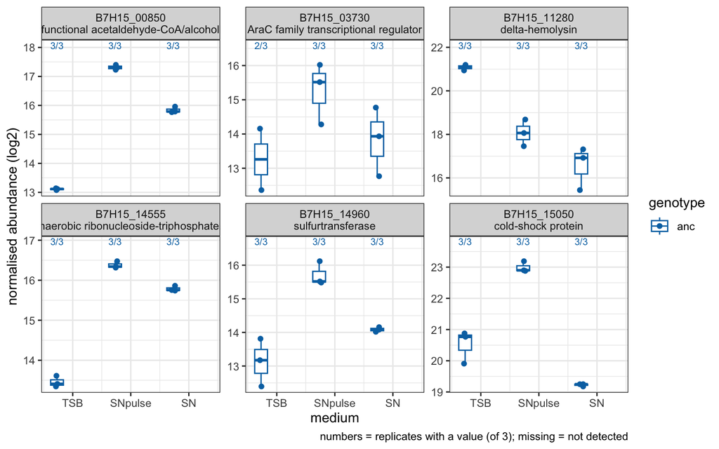

```r
# The 6 proteins with the strongest change (largest |log2FC|)
top6 <- early |> slice_max(abs(diff), n = 6) |> pull(protein_key)
plot_protein(top6, filter(ab, genotype == "anc"))
```

### 5.2 The list of early-changed proteins

```r
early |> select(-protein_key)
```

| locus_tag | product | staa8_uniprot | staa8_gene | diff | fold_change | direction | FDR |
| --- | --- | --- | --- | --- | --- | --- | --- |
| B7H15_00850 | bifunctional acetaldehyde-CoA/alcohol dehydrogenase | Q2G1K9 | NA | -4.188988 | 18.2 | higher after PASN | 0.0000000 |
| B7H15_14555 | anaerobic ribonucleoside-triphosphate reductase | Q2FV02 | NA | -2.946110 | 7.7 | higher after PASN | 0.0000000 |
| B7H15_03730 | AraC family transcriptional regulator | Q2G0D2 | NA | -2.611106 | 6.1 | higher after PASN | 0.0158264 |
| B7H15_14960 | sulfurtransferase | Q2FUS7 | TRHO | -2.482867 | 5.6 | higher after PASN | 0.0000011 |
| B7H15_15050 | cold-shock protein | Q2FUQ9 | NA | -2.416337 | 5.3 | higher after PASN | 0.0000130 |
| B7H15_01210 | pyruvate formate-lyase-activating enzyme | Q2G1D7 | PFLA | -2.368032 | 5.2 | higher after PASN | 0.0000299 |
| B7H15_11645 | transglycosylase SceD | Q2FWF8 | SCED | -2.290177 | 4.9 | higher after PASN | 0.0000001 |
| B7H15_09105 | glutamyl-tRNA reductase | Q2FXQ9 | HEM1 | -2.206257 | 4.6 | higher after PASN | 0.0000564 |
| B7H15_01295 | L-lactate dehydrogenase | Q2G218 | LDH1 | -2.187024 | 4.6 | higher after PASN | 0.0000000 |
| B7H15_01500 | glycyl-glycine endopeptidase LytM | O33599 | LYTM | -2.112457 | 4.3 | higher after PASN | 0.0000002 |
| B7H15_14550 | anaerobic ribonucleoside-triphosphate reductase activating protein | Q2FV03 | NA | -1.905847 | 3.7 | higher after PASN | 0.0009028 |
| B7H15_14290 | transglycosylase IsaA | Q2FV52 | ISAA | -1.873244 | 3.7 | higher after PASN | 0.0000001 |
| B7H15_14375 | type II secretion protein | Q2FV34 | NA | -1.838389 | 3.6 | higher after PASN | 0.0000000 |
| B7H15_06095 | hypothetical protein | Q2FZA8 | NA | -1.732537 | 3.3 | higher after PASN | 0.0251028 |
| B7H15_03360 | zinc-dependent alcohol dehydrogenase | Q2G0G1 | ADH | -1.700713 | 3.3 | higher after PASN | 0.0000000 |
| B7H15_14430 | aspartate 1-decarboxylase | Q2FV23 | PAND | -1.564800 | 3.0 | higher after PASN | 0.0019428 |
| B7H15_01680 | branched-chain amino acid transport system II carrier protein | Q2G171 | NA | -1.467290 | 2.8 | higher after PASN | 0.0285415 |
| B7H15_03650 | PTS-dependent dihydroxyacetone kinase phosphotransferase subunit DhaM | Q2G0E8 | NA | -1.465832 | 2.8 | higher after PASN | 0.0000016 |
| B7H15_14410 | VOC family protein | Q2FV27 | NA | -1.426443 | 2.7 | higher after PASN | 0.0000002 |
| B7H15_11815 | DNA-directed RNA polymerase subunit delta | Q2FWD0 | RPOE | -1.365239 | 2.6 | higher after PASN | 0.0000014 |
| B7H15_08310 | glyoxalase/bleomycin resistance/extradiol dioxygenase family protein | Q2FY61 | NA | -1.333590 | 2.5 | higher after PASN | 0.0019083 |
| B7H15_05770 | hypothetical protein | Q2G2C3 | Y1062 | -1.287087 | 2.4 | higher after PASN | 0.0000089 |
| B7H15_04460 | cold-shock protein | Q2G009 | NA | -1.247987 | 2.4 | higher after PASN | 0.0018782 |
| B7H15_06200 | cell division protein SepF | Q2FZ86 | SEPF | -1.213101 | 2.3 | higher after PASN | 0.0000802 |
| B7H15_06290 | VOC family protein | Q2G1U2 | NA | -1.163656 | 2.2 | higher after PASN | 0.0026476 |
| B7H15_10370 | transcriptional repressor | Q2G282 | PERR | -1.133660 | 2.2 | higher after PASN | 0.0074902 |
| B7H15_01615 | hypothetical protein | Q2G178 | ESSG | -1.086380 | 2.1 | higher after PASN | 0.0479980 |
| B7H15_04890 | Na+/H+ antiporter subunit E | Q2G2H8 | MNHE1 | 1.039807 | 2.1 | lower after PASN | 0.0002221 |
| B7H15_07185 | tautomerase | Q2G2M0 | NA | 1.095591 | 2.1 | lower after PASN | 0.0470938 |
| B7H15_01040 | isochorismatase | Q2G1H1 | NA | 1.162003 | 2.2 | lower after PASN | 0.0120590 |
| B7H15_00275 | hypothetical protein | Q2G1V8 | NA | 1.175566 | 2.3 | lower after PASN | 0.0405497 |
| B7H15_12270 | toxin | Q2FW51 | NA | 1.213541 | 2.3 | lower after PASN | 0.0075398 |
| B7H15_12155 | hypothetical protein | Q2FW65 | NA | 1.252165 | 2.4 | lower after PASN | 0.0018782 |
| NA | NA | NA | NA | 1.550803 | 2.9 | lower after PASN | 0.0075240 |
| B7H15_11280 | delta-hemolysin | Q2FWM8 | HLD | 3.010220 | 8.1 | lower after PASN | 0.0004036 |

```r
early |> count(direction)
```

| direction | n |
| --- | --- |
| higher after PASN | 27 |
| lower after PASN | 8 |

```r
knitr::include_graphics(file.path(REPO_ROOT, "reports", "string_evidence_network_34_nodes.svg"))
```

[figure not shown]

We get Protein ID for 34 out of 35 proteins -> look at this proteins in UniProt and String

Q2G1K9: Aldehyde-alcohol dehydrogenase, has catalytic activity in fermentation of pyruvate to ethanol Q2FV02: Anaerobic ribonucleoside-triphosphate reductase, putative: It makes DNA building blocks. It turns ribonucleoside triphosphates (ATP, GTP, CTP, UTP) into deoxyribonucleotides (dATP, dGTP and so on). The cell needs these to replicate and repair its DNA. It only works without oxygen

```r
# A result table (not raw data): may go to GitHub; Michelle can join it with her sites
write_csv(early, file.path(REPO_ROOT, "reports", "15min_changed_proteins_anc.csv"))
```

*Look up the most interesting ones in UniProt (`staa8_uniprot`) and note their function.*

### 5.3 Functional groups

The automatic categories are only a starting point: product names can be vague (“hypothetical protein”). Check in UniProt and correct them in `manual`.

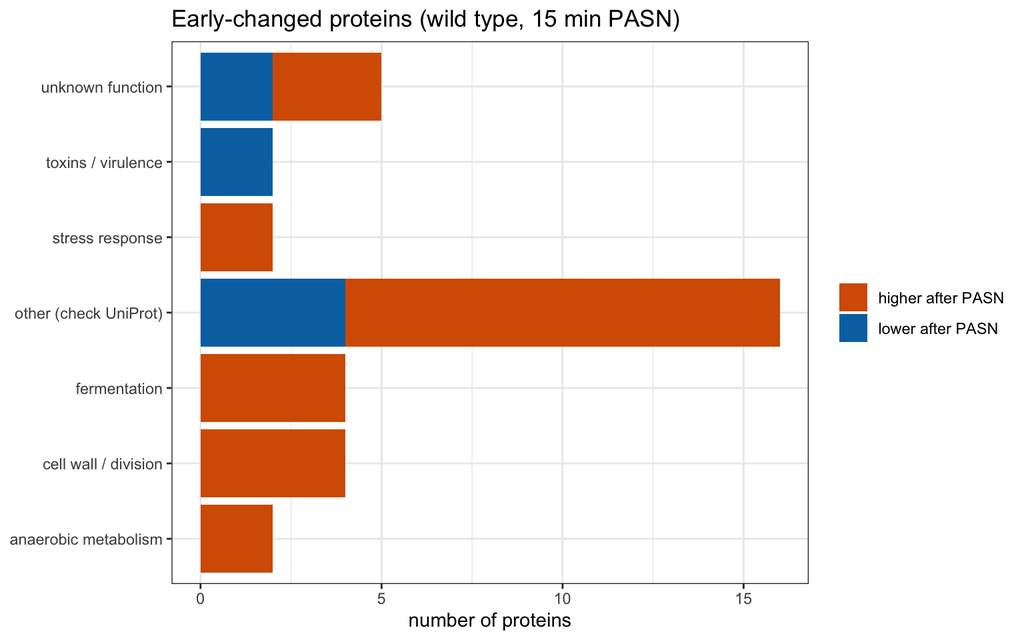

```r
early <- early |>
  mutate(category = case_when(
    str_detect(product, regex("alcohol dehydrogenase|lactate|formate|pyruvate|acetaldehyde",
                              ignore_case = TRUE)) ~ "fermentation",
    str_detect(product, regex("anaerobic|nitrate|nitrite",
                              ignore_case = TRUE)) ~ "anaerobic metabolism",
    str_detect(product, regex("transglycosylase|autolysin|amidase|endopeptidase|peptidoglycan|cell wall|cell division",
                              ignore_case = TRUE)) ~ "cell wall / division",
    str_detect(product, regex("toxin|hemolysin|leukocidin",
                              ignore_case = TRUE)) ~ "toxins / virulence",
    str_detect(product, regex("cold-shock|heat shock|stress",
                              ignore_case = TRUE)) ~ "stress response",
    str_detect(product, regex("transporter|ABC|permease|uptake",
                              ignore_case = TRUE)) ~ "transport",
    str_detect(product, regex("hypothetical|uncharacteri[sz]ed|DUF",
                              ignore_case = TRUE)) ~ "unknown function",
    .default = "other (check UniProt)"))

# Your corrections after reading UniProt: one row per protein you re-assign
manual <- tibble::tribble(
  ~locus_tag,     ~category_manual,
  "B7H15_00000",  "example (delete this row)"
)

early <- early |>
  left_join(manual, by = "locus_tag") |>
  mutate(category = coalesce(category_manual, category)) |>
  select(-category_manual)

early |>
  ggplot(aes(y = category, fill = direction)) +
  geom_bar() +
  scale_fill_manual(values = c("higher after PASN" = "#D55E00",
                               "lower after PASN"  = "#0072B2")) +
  labs(x = "number of proteins", y = NULL, fill = NULL,
       title = "Early-changed proteins (wild type, 15 min PASN)")
```

*Is fermentation / anaerobic metabolism the biggest group (H1)? Which groups go up, which down?*

### 5.4 On/off proteins (excluded from the counts) still look at this topic!

Detected in all 3 replicates in one medium and in none of the other. **Presence/absence evidence only**: no reliable fold change.

```r
on_off <- n_obs |>
  filter(genotype == "anc") |>
  mutate(pattern = case_when(
    TSB == 3 & SNpulse == 0 ~ "only in TSB (lost after PASN)",
    TSB == 0 & SNpulse == 3 ~ "only after PASN (appears)",
    .default = NA)) |>
  filter(!is.na(pattern)) |>
  left_join(select(read_annotation(), protein_key, locus_tag, product, staa8_uniprot),
            by = "protein_key")

on_off |> count(pattern)
```

| pattern | n |
| --- | --- |
| only after PASN (appears) | 8 |
| only in TSB (lost after PASN) | 8 |

```r
on_off |> select(pattern, locus_tag, product, staa8_uniprot, TSB, SNpulse)
```

| pattern | locus_tag | product | staa8_uniprot | TSB | SNpulse |
| --- | --- | --- | --- | --- | --- |
| only after PASN (appears) | B7H15_02210 | hypothetical protein | Q2G1S8 | 0 | 3 |
| only in TSB (lost after PASN) | B7H15_02930 | protein translocase subunit SecE | P0A0I4 | 3 | 0 |
| only in TSB (lost after PASN) | B7H15_04625 | pathogenicity island protein | Q2G1H1 | 3 | 0 |
| only after PASN (appears) | B7H15_04655 | hypothetical protein | Q2G065 | 0 | 3 |
| only after PASN (appears) | B7H15_07940 | hypothetical protein | Q2G2K4 | 0 | 3 |
| only in TSB (lost after PASN) | B7H15_08070 | dUTPase | Q2FWS5 | 3 | 0 |
| only after PASN (appears) | B7H15_12245 | MerR family transcriptional regulator | Q2FW56 | 0 | 3 |
| only after PASN (appears) | B7H15_13800 | hypothetical protein | Q2FVD2 | 0 | 3 |
| only in TSB (lost after PASN) | B7H15_14585 | glutathione peroxidase | Q2FUZ6 | 3 | 0 |
| only after PASN (appears) | B7H15_14655 | transcriptional regulator | Q2FUY1 | 0 | 3 |
| only in TSB (lost after PASN) | B7H15_14805 | methionine sulfoxide reductase A | Q2FUV5 | 3 | 0 |
| only in TSB (lost after PASN) | NA | NA | NA | 3 | 0 |
| only in TSB (lost after PASN) | NA | NA | NA | 3 | 0 |
| only after PASN (appears) | NA | NA | NA | 0 | 3 |
| only after PASN (appears) | NA | NA | NA | 0 | 3 |
| only in TSB (lost after PASN) | NA | NA | NA | 3 | 0 |

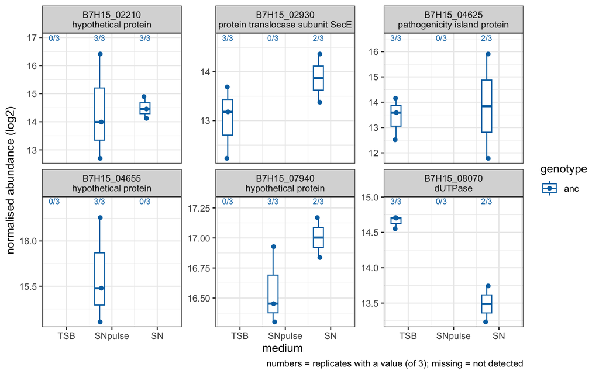

```r
if (nrow(on_off) > 0) plot_protein(head(on_off$protein_key, 6), filter(ab, genotype == "anc"))
```

### 5.5 Do the early proteins carry phosphosites?

```r
phos_early <- read_dea("phospho_STYH", contrasts = "TSB_vs_SNpulse_at_anc") |>
  filter(protein_key %in% early$protein_key) |>
  select(locus_tag, product, residue, position, diff, FDR, estimate_type) |>
  arrange(locus_tag, position)

n_distinct(phos_early$locus_tag)   # how many of the 35 have >= 1 phosphosite
```

```
[1] 17
```

```r
phos_early
```

| locus_tag | product | residue | position | diff | FDR | estimate_type |
| --- | --- | --- | --- | --- | --- | --- |
| B7H15_00850 | bifunctional acetaldehyde-CoA/alcohol dehydrogenase | T | 3 | 0.0000000 | 1.0000000 | lod_imputed |
| B7H15_00850 | bifunctional acetaldehyde-CoA/alcohol dehydrogenase | T | 131 | -0.3094390 | 1.0000000 | lod_imputed |
| B7H15_00850 | bifunctional acetaldehyde-CoA/alcohol dehydrogenase | T | 132 | -0.3094390 | 1.0000000 | lod_imputed |
| B7H15_00850 | bifunctional acetaldehyde-CoA/alcohol dehydrogenase | T | 304 | 0.0000000 | 1.0000000 | lod_imputed |
| B7H15_00850 | bifunctional acetaldehyde-CoA/alcohol dehydrogenase | S | 314 | 0.0000000 | 1.0000000 | lod_imputed |
| B7H15_00850 | bifunctional acetaldehyde-CoA/alcohol dehydrogenase | T | 330 | 0.0000000 | 1.0000000 | lod_imputed |
| B7H15_00850 | bifunctional acetaldehyde-CoA/alcohol dehydrogenase | S | 411 | -0.9472349 | 1.0000000 | lod_imputed |
| B7H15_00850 | bifunctional acetaldehyde-CoA/alcohol dehydrogenase | S | 811 | 0.0000000 | 1.0000000 | lod_imputed |
| B7H15_00850 | bifunctional acetaldehyde-CoA/alcohol dehydrogenase | S | 820 | 0.0000000 | 1.0000000 | lod_imputed |
| B7H15_01295 | L-lactate dehydrogenase | S | 297 | 0.0000000 | 1.0000000 | lod_imputed |
| B7H15_01500 | glycyl-glycine endopeptidase LytM | S | 194 | 0.0000000 | 1.0000000 | lod_imputed |
| B7H15_01500 | glycyl-glycine endopeptidase LytM | S | 315 | 0.0000000 | 1.0000000 | lod_imputed |
| B7H15_03360 | zinc-dependent alcohol dehydrogenase | S | 13 | 0.0000000 | 1.0000000 | lod_imputed |
| B7H15_03360 | zinc-dependent alcohol dehydrogenase | S | 213 | 0.0000000 | 1.0000000 | lod_imputed |
| B7H15_03360 | zinc-dependent alcohol dehydrogenase | T | 226 | 0.0000000 | 1.0000000 | lod_imputed |
| B7H15_03360 | zinc-dependent alcohol dehydrogenase | T | 237 | 0.0000000 | 1.0000000 | lod_imputed |
| B7H15_03360 | zinc-dependent alcohol dehydrogenase | S | 238 | 0.0000000 | 1.0000000 | lod_imputed |
| B7H15_03360 | zinc-dependent alcohol dehydrogenase | T | 242 | 0.0000000 | 1.0000000 | lod_imputed |
| B7H15_03650 | PTS-dependent dihydroxyacetone kinase phosphotransferase subunit DhaM | S | 19 | 0.0000000 | 1.0000000 | lod_imputed |
| B7H15_03650 | PTS-dependent dihydroxyacetone kinase phosphotransferase subunit DhaM | T | 53 | 0.0000000 | 1.0000000 | lod_imputed |
| B7H15_04460 | cold-shock protein | S | 24 | 1.7532463 | 0.1068721 | lod_imputed |
| B7H15_04460 | cold-shock protein | H | 29 | 0.5637896 | 1.0000000 | lod_imputed |
| B7H15_04460 | cold-shock protein | S | 31 | 2.0197898 | 0.0933586 | lod_imputed |
| B7H15_05770 | hypothetical protein | S | 82 | 0.0000000 | 1.0000000 | lod_imputed |
| B7H15_06200 | cell division protein SepF | S | 94 | 0.0000000 | 1.0000000 | lod_imputed |
| B7H15_06200 | cell division protein SepF | S | 97 | 0.0000000 | 1.0000000 | lod_imputed |
| B7H15_06200 | cell division protein SepF | S | 98 | 0.0000000 | 1.0000000 | lod_imputed |
| B7H15_06290 | VOC family protein | T | 87 | 0.7803218 | 1.0000000 | lod_imputed |
| B7H15_09105 | glutamyl-tRNA reductase | T | 359 | 0.0000000 | 1.0000000 | lod_imputed |
| B7H15_09105 | glutamyl-tRNA reductase | S | 362 | 0.0000000 | 1.0000000 | lod_imputed |
| B7H15_11280 | delta-hemolysin | T | 26 | 0.0000000 | 1.0000000 | lod_imputed |
| B7H15_11645 | transglycosylase SceD | T | 177 | 0.0000000 | 1.0000000 | lod_imputed |
| B7H15_11645 | transglycosylase SceD | S | 178 | 0.0000000 | 1.0000000 | lod_imputed |
| B7H15_11815 | DNA-directed RNA polymerase subunit delta | T | 22 | 0.0000000 | 1.0000000 | lod_imputed |
| B7H15_11815 | DNA-directed RNA polymerase subunit delta | Y | 34 | 0.0000000 | 1.0000000 | lod_imputed |
| B7H15_11815 | DNA-directed RNA polymerase subunit delta | T | 94 | 0.0000000 | 1.0000000 | lod_imputed |
| B7H15_12270 | toxin | T | 10 | 0.0000000 | 1.0000000 | lod_imputed |
| B7H15_12270 | toxin | T | 18 | 0.0000000 | 1.0000000 | lod_imputed |
| B7H15_14290 | transglycosylase IsaA | S | 184 | -3.3729200 | 0.0003800 | lod_imputed |
| B7H15_14290 | transglycosylase IsaA | Y | 191 | -2.1313137 | 1.0000000 | observed |
| B7H15_14290 | transglycosylase IsaA | S | 194 | -2.7974115 | 0.0320037 | observed |
| B7H15_14290 | transglycosylase IsaA | S | 197 | -2.7772416 | 0.3070912 | observed |
| B7H15_14290 | transglycosylase IsaA | T | 202 | -2.5489789 | 0.0076023 | lod_imputed |
| B7H15_14290 | transglycosylase IsaA | T | 209 | 0.0000000 | 1.0000000 | lod_imputed |
| B7H15_14290 | transglycosylase IsaA | T | 211 | -0.1830945 | 1.0000000 | lod_imputed |
| B7H15_14290 | transglycosylase IsaA | Y | 223 | 0.0000000 | 1.0000000 | lod_imputed |
| B7H15_14555 | anaerobic ribonucleoside-triphosphate reductase | T | 29 | 0.0000000 | 1.0000000 | lod_imputed |
| B7H15_14555 | anaerobic ribonucleoside-triphosphate reductase | T | 316 | -2.1494267 | 0.1491007 | lod_imputed |
| B7H15_14555 | anaerobic ribonucleoside-triphosphate reductase | S | 326 | -2.1494267 | 0.1491007 | lod_imputed |
| B7H15_14555 | anaerobic ribonucleoside-triphosphate reductase | T | 331 | -2.1494267 | 0.1491007 | lod_imputed |
| B7H15_14960 | sulfurtransferase | T | 309 | 0.0000000 | 1.0000000 | lod_imputed |

You could write in your report: “17 of the 35 changed proteins carry detected phosphosites, but 48 of 51 site estimates were based on imputed values. Apart from IsaA, whose sites followed the protein increase, we found no reliable phosphorylation changes on these proteins.”

## 6. Caveats

- *Only 3 replicates; FDR sensitive to single outlying samples.*
- *Categories from product names / UniProt are approximate; many “hypothetical proteins”.*
- *On/off proteins have no fold change; they may be close to the detection limit.*
- *Protein abundance ≠ activity (e.g. enzymes can be regulated by phosphorylation).*

## 8. Sources

*Papers, databases (UniProt IDs for every protein you describe, STRING), and AI tools used – with what for, and what you checked yourself.*

- Niggli et al., mBio (2023), doi:10.1128/mbio.03153-22 (PASN and HQNO effects on *S. aureus*)
- Schwyter et al., mSystems (2025), doi:10.1128/msystems.00262-25 (proteome response of JE2 to PASN)

## 9. Summary: functions of the early-changed proteins and link to the literature

After 15 min of *P. aeruginosa* supernatant (PASN), 34 *S. aureus* JE2 proteins change: **27 go up and 7 go down**. The strongest signal is a switch to **fermentation and anaerobic metabolism**, while **toxins (delta-hemolysin) go down**.

- **Data:** wild type (anc), contrast `TSB_vs_SNpulse_at_anc`, changed = FDR < 0.05 and |log2FC| > 1 (`reports/15min_changed_proteins_anc.csv`).
- **35th hit:** `zz_Y-FGCZCont00173_` is an FGCZ lab contaminant, not an *S. aureus* protein. It should be removed, so the real count is 34.
- **Fold changes** below are linear fold changes (2^|log2FC|).
- **Pattern:** the up-regulated proteins look like a response to blocked respiration, oxidative stress and cell-wall stress, consistent with HQNO, pyocyanin and cyanide in PASN. The down-regulated proteins include *agr*-controlled toxins.
- Functions are taken from the JE2 genome annotation (NCBI) and from the STRING v12 descriptions of the NCTC 8325 orthologs, and still have to be confirmed in UniProt / AureoWiki. 17 of the 34 proteins are called “Conserved hypothetical protein” in STRING; section 9.3 shows how well characterised each of them really is.

### 9.1 Upregulated after PASN (27 proteins)

#### Fermentation and anaerobic metabolism (6)

When respiration is blocked, *S. aureus* regenerates NAD+ by fermenting pyruvate to lactate, ethanol and formate instead of using the electron transport chain.

| Protein (gene) | UniProt | Fold up | Function |
| --- | --- | --- | --- |
| Bifunctional acetaldehyde-CoA/alcohol dehydrogenase (AdhE) | Q2G1K9 | 18.2 | Acetyl-CoA → acetaldehyde → ethanol; key NAD+ regeneration step of fermentation |
| Anaerobic ribonucleoside-triphosphate reductase (NrdD) | Q2FV02 | 7.7 | Makes DNA building blocks (dNTPs) without oxygen; glycyl-radical enzyme |
| Pyruvate formate-lyase-activating enzyme (PflA) | Q2G1D7 | 5.2 | Activates pyruvate formate-lyase (pyruvate → acetyl-CoA + formate), the anaerobic route out of pyruvate |
| L-lactate dehydrogenase (Ldh1) | Q2G218 | 4.6 | Pyruvate → lactate; Ldh1 is induced by NO and respiratory stress |
| NrdD-activating protein (NrdG) | Q2FV03 | 3.7 | Radical SAM enzyme that switches on NrdD; same operon |
| Zinc-dependent alcohol dehydrogenase (Adh) | Q2G0G1 | 3.3 | Acetaldehyde ↔︎ ethanol, NAD+ regeneration |

These six form the largest connected cluster in the STRING network

#### Cell wall and cell division (4)

| Protein (gene) | UniProt | Fold up | Function |
| --- | --- | --- | --- |
| Transglycosylase SceD | Q2FWF8 | 4.9 | Peptidoglycan remodelling, cell separation; induced by cell-wall stress |
| Glycyl-glycine endopeptidase LytM | O33599 | 4.3 | Cuts pentaglycine bridges in peptidoglycan (autolysin) |
| Transglycosylase IsaA | Q2FV52 | 3.7 | Peptidoglycan hydrolase, “immunodominant staphylococcal antigen A” |
| Cell division protein SepF | Q2FZ86 | 2.3 | Anchors the FtsZ ring to the membrane during division |

SceD, LytM and IsaA are co-regulated autolysins (WalKR regulon), suggesting cell-envelope remodelling or stress.

#### Stress response and regulation (6)

| Protein (gene) | UniProt | Fold up | Function |
| --- | --- | --- | --- |
| AraC family transcriptional regulator | Q2G0D2 | 6.1 | Transcription regulator, target unknown; weakest FDR (0.016) |
| Sulfurtransferase (TrhO) | Q2FUS7 | 5.6 | tRNA uridine hydroxylation; rhodanese family members can detoxify cyanide |
| Cold-shock protein | Q2FUQ9 | 5.3 | RNA chaperone (CspA-like); in *S. aureus* also linked to stress and pigment regulation |
| Cold-shock protein | Q2G009 | 2.4 | Second Csp paralog |
| DNA-directed RNA polymerase subunit delta (RpoE) | Q2FWD0 | 2.6 | Small RNAP subunit that improves promoter specificity |
| Peroxide-responsive repressor (PerR) | Q2G282 | 2.2 | Senses H2O2 and controls KatA, AhpC and iron storage; a direct sign of oxidative stress |

#### Detoxification (3)

| Protein (gene) | UniProt | Fold up | Function |
| --- | --- | --- | --- |
| VOC family protein | Q2FV27 | 2.7 | Vicinal-oxygen-chelate enzyme; glyoxalase-like, detoxifies reactive carbonyls or antibiotics |
| Glyoxalase/bleomycin resistance/dioxygenase family | Q2FY61 | 2.5 | Same fold; methylglyoxal detox or ring-cleavage |
| VOC family protein | Q2G1U2 | 2.2 | Same fold |

Methylglyoxal accumulates when glycolysis runs faster than downstream steps, which happens during fermentation.

#### Other metabolism, transport and secretion (6)

| Protein (gene) | UniProt | Fold up | Function |
| --- | --- | --- | --- |
| Glutamyl-tRNA reductase (HemA) | Q2FXQ9 | 4.6 | First step of heme biosynthesis; heme is needed for cytochromes and catalase |
| Type II secretion protein | Q2FV34 | 3.6 | Membrane/secretion protein, function unclear in *S. aureus* |
| Aspartate 1-decarboxylase (PanD) | Q2FV23 | 3.0 | Pantothenate (vitamin B5) → coenzyme A synthesis |
| Branched-chain amino acid carrier (BrnQ-like) | Q2G171 | 2.8 | Imports Ile, Leu, Val; weak FDR (0.029) |
| Dihydroxyacetone kinase subunit DhaM | Q2G0E8 | 2.8 | PTS-dependent phosphorylation of dihydroxyacetone, feeds glycolysis |
| EssG | Q2G178 | 2.1 | Component of the type VII secretion system (Ess); antitoxin that neutralises the toxin EssD (STRING); FDR 0.048, borderline |

#### Unknown function (2)

| Protein (gene) | UniProt | Fold up | Function |
| --- | --- | --- | --- |
| Hypothetical protein | Q2FZA8 | 3.3 | Unknown in both JE2 and STRING annotation; FDR 0.025 |
| Hypothetical protein (SAOUHSC_01062) | Q2G2C3 | 2.4 | Unknown; STRING: UPF0358 family (uncharacterised protein family) |

### 9.2 Downregulated after PASN (7 proteins)

The strongest drop is delta-hemolysin (8.1-fold), which points to an early decrease in *agr*-controlled virulence. A second virulence-related protein, the MHC class II analog protein (Q2FW51), also goes down.

[output not shown]

The contaminant `zz_Y-FGCZCont00173_` (2.9-fold down) is left out on purpose.

### 9.3 How well characterised are these proteins?

STRING (v12, NCTC 8325 orthologs) calls 17 of the 34 proteins “Conserved hypothetical protein”. The JE2 genome annotation is newer and gives many of them a name based on a sequence domain or family. Comparing both annotations gives three levels:

**A. “Hypothetical” in STRING, but STRING’s description gives a known function (4)**

| Protein | UniProt | Direction | STRING description |
| --- | --- | --- | --- |
| NrdG | Q2FV03 | up | Activates the anaerobic ribonucleotide reductase (radical SAM enzyme) |
| SepF | Q2FZ86 | up | Divisome protein, recruited early to the Z-ring, cross-links FtsZ |
| EssG | Q2G178 | up | Type VII secretion (Ess) component; antitoxin of EssD |
| MnhE1 | Q2G2H8 | down | Part of the Mnh Na+/H+ antiporter |

**B. “Hypothetical” in STRING; JE2 only gives a family or domain name (9)**

These have a *predicted* activity from their sequence, but no studied role in *S. aureus*.

| JE2 name | UniProt | Direction |
| --- | --- | --- |
| AraC family transcriptional regulator | Q2G0D2 | up |
| Sulfurtransferase (UPF0176 family) | Q2FUS7 | up |
| Type II secretion protein | Q2FV34 | up |
| Dihydroxyacetone kinase subunit DhaM | Q2G0E8 | up |
| VOC family protein | Q2FV27 | up |
| Glyoxalase/bleomycin resistance family protein | Q2FY61 | up |
| VOC family protein | Q2G1U2 | up |
| Cold-shock protein | Q2G009 | up |
| Isochorismatase family protein | Q2G1H1 | down |

**C. Hypothetical in both annotations, i.e. truly unknown (4)**

Q2FZA8 (up), Q2G2C3 (up; UPF0358 family), Q2G1V8 (down), Q2FW65 (down).

So about half of the early-changed proteins (17 of 34) are poorly characterised, and interpretations of groups B and C should be treated as hypotheses.

### 9.4 Connection to the course papers

The 15 min proteins fit the long-term picture from the papers (blocked respiration, oxidative stress, less virulence) and show that part of this response has already started after 15 min.

What the supernatant contains: P. aeruginosa secretes HQNO and PQS, which block respiration and create reactive oxygen species (ROS). It also secretes pyocyanin, hydrogen cyanide, the LasA protease and siderophores. Schwyter et al. 2025 and Niggli et al. show that PASN inhibits S. aureus growth.

| Finding (15 min) | Paper | What the paper shows | How it connects |
| --- | --- | --- | --- |
| Fermentation up (AdhE, Ldh1, PflA, Adh) and NrdDG up | Review “Harnessing bacterial interactions” | *P. aeruginosa* HQNO shifts *S. aureus* from respiration to fermentation; linked to small colony variants (SCVs) and antibiotic tolerance | Direct support: the shift is visible at protein level after only 15 min |
| PerR up; cold-shock proteins, VOC/glyoxalase enzymes up | Schwyter et al. 2025 (mSystems) | After 18 h in 30% PASN, JE2 raises the ROS scavengers SodA, KatA and AhpC; HQNO and PQS generate ROS | PerR is the H2O2 sensor that controls KatA and AhpC, so this may be the start of that response. Check whether KatA, AhpC and SodA already move at 15 min |
| Delta-hemolysin (Hld) and the MHC class II analog protein (Q2FW51) down | Schwyter et al. 2025 | Virulence factors are the main down-regulated group after 18 h (Hla, LukD, LukG, LukH ≈ 32-fold down); the toxin repressor Rot goes up | Same direction, but a smaller set. Hld comes from RNAIII, so *agr* may already be switching off |
| MnhE1 down; BrnQ-like carrier up | Schwyter et al. 2025 | Transporters are mostly down after 18 h (26 down vs 8 up), including Na+ and peptide importers | Partly consistent; at 15 min only one transporter subunit goes down |
| Fermentation, SCV-like state | Niggli et al. (mBio) | JE2 and other strains adapt to PASN over 30 days; SCVs appear in PASN-evolved populations; hemolysis changes during evolution | The early metabolic switch is the plastic (non-genetic) response that evolution later builds on |
| Cell-wall hydrolases (SceD, LytM, IsaA) and SepF up | Huemer et al. 2023 (Sci Signal) | PknB/Stp phosphorylation regulates cell wall synthesis, cell division (FtsZ) and translation; stress leads to quiescence and antibiotic tolerance | Cell-wall and division proteins are typical PknB targets; check the phospho data for changed sites on them |
| Fast changes in few proteins | Prust et al. 2021 (MCP) | *S. aureus* has more than 3800 phosphosites and few sigma factors, so much regulation happens by phosphorylation | Supports the topic-1 hypothesis: phosphorylation should react faster and more broadly than protein levels |
| Anaerobic switch, delta-hemolysin down | CF review (*P. aeruginosa* adaptation to the CF airway) | CF lungs contain low-oxygen mucus where *P. aeruginosa* and *S. aureus* co-exist | Clinical relevance: the anaerobic, low-virulence state may help *S. aureus* persist in CF co-infection (statement still to be checked in the paper) |

In short, the 15 min data show the beginning of the 18 h response described by Schwyter et al.: metabolism and stress sensors change first, while the large virulence and transporter changes probably need more time (topic 3).

### 9.5 Open points

- Confirm the key functions in UniProt or AureoWiki, especially Q2FW51 (“toxin” in JE2 vs MHC class II analog protein in STRING), the AraC regulator and the VOC proteins (group B in 9.3).
- Borderline hits (FDR 0.016–0.048): AraC regulator, BrnQ-like carrier, Q2FZA8, EssG, Q2G1V8, tautomerase.
- An 18-fold increase of AdhE in 15 min is surprisingly large: check the raw values (5.1) and whether it was near the detection limit in TSB.
- Remove the contaminant in notebooks 07 and 08 and update the count to 34.
- Next: are SodA, KatA, AhpC, CydA and Rot already changed at 15 min? Do the cell-wall and fermentation proteins carry changed phosphosites (5.5)?

**Additional references:** Huemer et al., Sci. Signal. (2023) 16, eabj8194, doi:10.1126/scisignal.abj8194 · Prust et al., Mol. Cell. Proteomics (2021) 20, 100034, doi:10.1074/mcp.RA120.002232 · Review “Harnessing bacterial interactions to manage infections – *P. aeruginosa* as a case example” · Review “Adaptation of *P. aeruginosa* to the cystic fibrosis airway – an evolutionary perspective”